# Trabajo Final Módulo Ciencia de Datos

Manuel González Petersen

05/04/2020

# Análisis Exploratorio

Lo realizaremos con el conjunto completo de datos

- Identifica para columna el tipo de dato (character, factor, numeric, etc) en el que ha sido almacenado

```
##       customerID           gender    SeniorCitizen          Partner       Dependents
##      "character"         "factor"         "factor"         "factor"         "factor"
##           tenure     PhoneService    MultipleLines  InternetService   OnlineSecurity
##        "integer"         "factor"         "factor"         "factor"         "factor"
##     OnlineBackup DeviceProtection      TechSupport      StreamingTV  StreamingMovies
##         "factor"         "factor"         "factor"         "factor"         "factor"
##         Contract PaperlessBilling    PaymentMethod   MonthlyCharges     TotalCharges
##         "factor"         "factor"         "factor"        "numeric"        "numeric"
##            Churn
##         "factor"
```

- Visualiza un resumen del conjunto de datos mediante la función summary.

[output not shown]

- De cara a la predicción del churn, para cada una de las variables excepto el customerID:

  o Realiza un diagrama de frecuencias para las variables cualitativas o histogramas para las variables cuantitativas

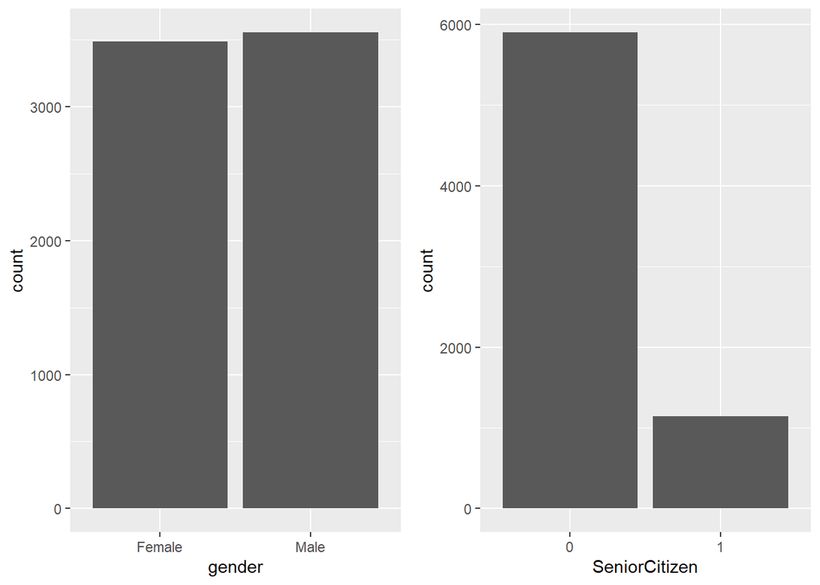

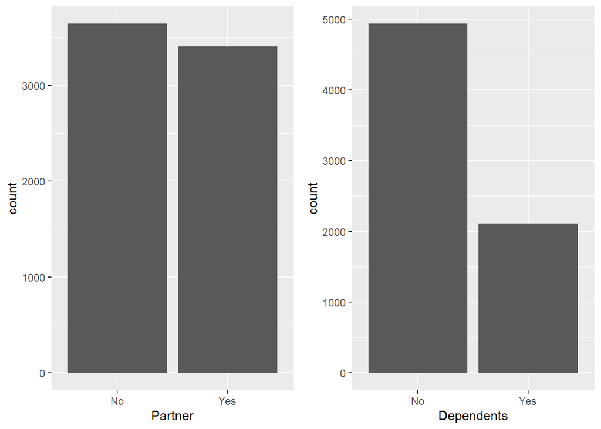

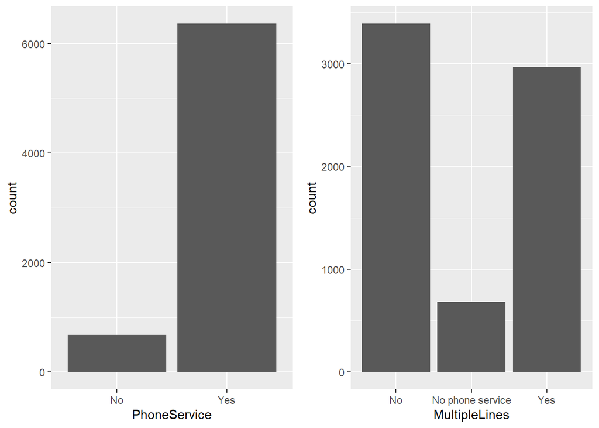

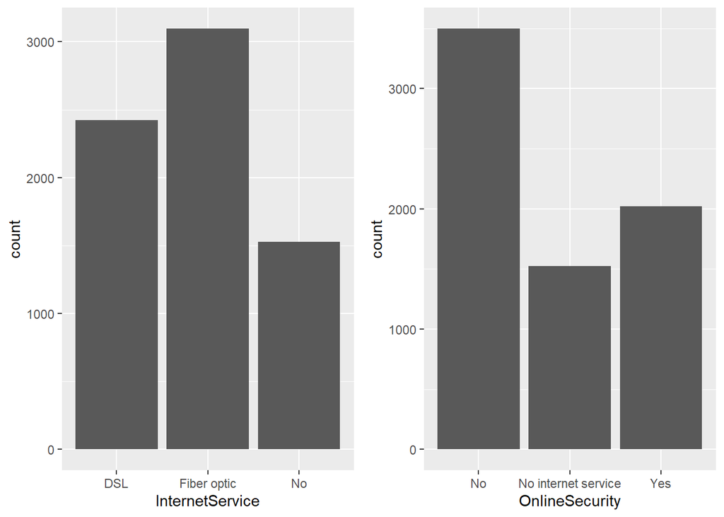